# Numerical Methods in Accelerator Physics

### Demo lecture: phase-space tomography

##### Notebook lecture by [Dr. Adrian Oeftiger $\nearrow$](http://web-docs.gsi.de/~aoeftige)

at TU Darmstadt etit, Fachbereichsrats-Sitzung, on 27.09.2022.

(hit space to go to the next slide)

#### Run this notebook online:

Also find this lecture rendered [on github $\nearrow$](https://aoeftiger.github.io/TUDa-demo-lecture-tomo/) along with the [source repository $\nearrow$](https://github.com/aoeftiger/TUDa-demo-lecture-tomo/):

https://github.com/aoeftiger/TUDa-demo-lecture-tomo

# Tomographic Reconstruction

**"Tomography"**: imaging via sectioning

**Origins**: mathematician J. Radon (AUT)

- 1917: "On the determination of functions from their integrals along certain manifolds"
- inverse problem
- **Fourier slice theorem**: any 2D (3D) object can be reconstructed from infinite set of 1D (2D) projections

[figure not shown]

# Many Applications

- medical: CT scan in hospitals (computed tomography)
  - 1979 Nobel price in Medicine:  
    first CT scanner by Sir G.N. Hounsfield
- material science
- airport security
- accelerator physics
- ...

# Projection Integral or Radon Transform $\mathcal{R}_\theta(p)$

$$\require{color} \mathcal{R}_\theta(p)\, f = \int dx\int dy~ f(x, y) \,\underbrace{\delta(x\,\cos \theta+y\,\sin\theta-p)}\limits_{\color{red}\text{projection slice}}$$

[figure not shown]

image source: [@docmilanfar, Twitter](https://twitter.com/docmilanfar/status/1366229985975930881/photo/1)

```python
# imports
from talksetup import *
%matplotlib inline

from skimage.transform import radon, iradon
from PIL import Image
```

Load sample image for the tomography:

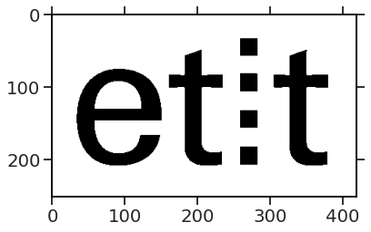

```python
data = ~np.array(Image.open('etit_logo.png').convert('1', dither=False))

plt.imshow(data, cmap='binary')
```

Compute the Radon transform at an angle of 0 deg and 90 deg:

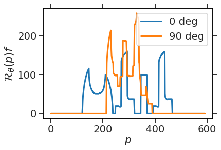

```python
Rf_0 = radon(data, [0], circle=False).astype(float)
Rf_90 = radon(data, [90], circle=False).astype(float)

plt.plot(Rf_0, label='0 deg')
plt.plot(Rf_90, label='90 deg')
plt.legend()
plt.xlabel('$p$')
plt.ylabel(r'$\mathcal{R}_{\theta}(p)f$');
```

# Reconstruction Principle

[figure not shown]

images source: [CERN tomography website](https://tomograp.web.cern.ch/home_page/iter_tomo/iter_tomo/)

projection (measurement) $\implies$ back-projection (reconstruction)

(Require $ N_{meas} \gtrsim \pi\cdot\frac{\text{total diameter}}{\text{pixel size}}$)

```python
# parameters
N = max(data.shape)
ANG = 180
VIEW = 180
THETA = np.linspace(0, ANG, VIEW, endpoint=False)
```

```python
# definitions of matrix transforms
A = lambda x: radon(x, THETA, circle=False).astype(float)
AT = lambda y: iradon(y, THETA, circle=False, filter=None,
                      output_size=N).astype(float) * 2 * len(THETA) / np.pi
AINV = lambda y: iradon(y, THETA, circle=False, output_size=N).astype(float)
```

```python
proj = A(data)
```

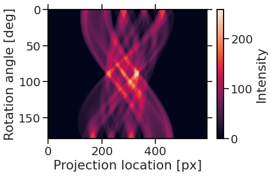

```python
plt.imshow(proj.T)

plt.gca().set_aspect('auto')
plt.xlabel('Projection location [px]')
plt.ylabel('Rotation angle [deg]')
plt.colorbar(label='Intensity');
```

```python
fbp = AINV(proj)
```

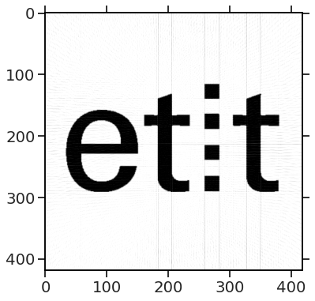

```python
plt.figure(figsize=(12, 6))
plt.imshow(fbp, cmap='binary', vmin=0, vmax=1);
```

# Improved Reconstruction Principle

[figure not shown]

images source: [CERN tomography website](https://tomograp.web.cern.ch/home_page/iter_tomo/iter_tomo/)

projection (measurement) $\implies$ back-projection (reconstruction)

$\stackrel{\text{improve}}{\implies}$ re-projection (red) $\implies$ iteratively reduce discrepancy

# Reconstruction Algorithms

[figure not shown]

**Filtered Back-Projection (FBP)** vs. **Iterative** Reconstruction

$\implies$ Iterative **algebraic reconstruction technique (ART)**:

- more computationally expensive than FBP
- more accurate, less artifacts
- can incorporate *a priori* knowledge

```python
noise = np.random.normal(0, 0.2 * np.max(proj), size=proj.shape)
```

```python
proj_noise = proj + noise
```

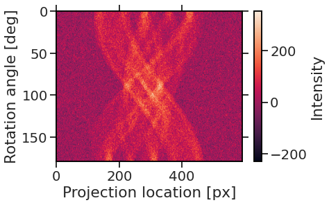

```python
plt.imshow(proj_noise.T)
plt.gca().set_aspect('auto')
plt.xlabel('Projection location [px]')
plt.ylabel('Rotation angle [deg]')
plt.colorbar(label='Intensity');
```

```python
fbp_noise = AINV(proj_noise)
```

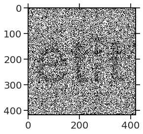

```python
plt.imshow(fbp_noise, cmap='binary', vmin=0, vmax=1, interpolation='None');
```

```python
def ART(A, AT, b, x, mu=1, niter=10):
    ATA = AT(A(np.ones_like(x)))

    for i in tqdm(range(niter)):
        x = x + np.divide(mu * AT(b - A(x)), ATA)

        # nonlinearity: constrain to >= 0 values
        x[x < 0] = 0

        plt.imshow(x, cmap='binary', vmin=0, vmax=1, interpolation='None')
        plt.title("%d / %d" % (i + 1, niter))
        plt.show()

    return x

# initialisation
x0 = np.zeros((N, N))
mu = 1
niter = 10
```

[figure not shown]

[figure not shown]

[figure not shown]

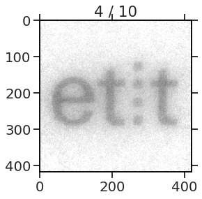

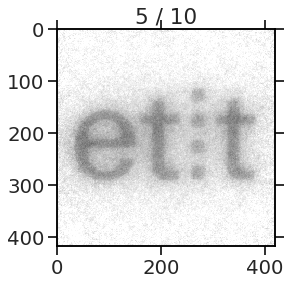

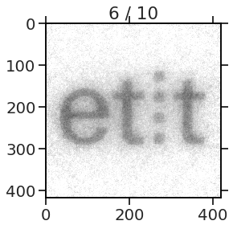

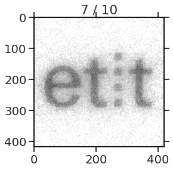

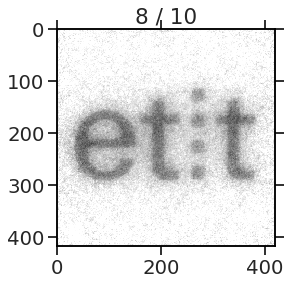

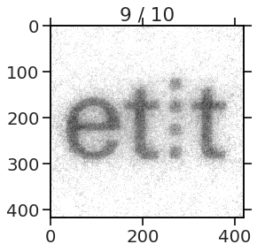

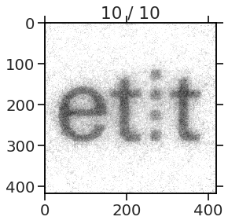

```python
x_art = ART(A, AT, proj_noise, x0, mu, niter)
```

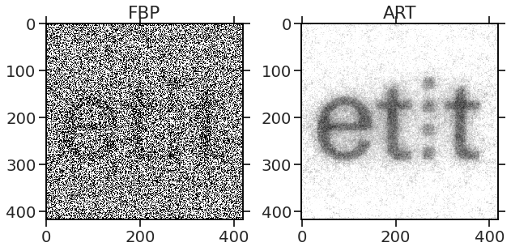

```python
_, ax = plt.subplots(1, 2, figsize=(10, 5))
plt.subplots_adjust(wspace=0.3)

plt.sca(ax[0])
plt.imshow(fbp_noise, cmap='binary', vmin=0, vmax=1, interpolation='None')
plt.title('FBP')

plt.sca(ax[1])
plt.imshow(x_art, cmap='binary', vmin=0, vmax=1, interpolation='None')
plt.title('ART');
```

# Tomography in Accelerator Physics

Longitudinal phase space reconstruction (modified ART) in a synchrotron!

## Simulation:

[figure not shown]

# Tomography in Accelerator Physics

Longitudinal phase space reconstruction (modified ART) in a synchrotron!

## Reconstruction:

[figure not shown]

# Summary

- Radon transform
- Tomographic reconstruction algorithms:
  - filtered back-projection
  - iterative: algebraic reconstruction technique

$\implies$ Go ahead, try out the accelerator physics example $\nearrow$

Further literature: [Chapter 3 of A. C. Kak and Malcolm Slaney, Principles of Computerized Tomographic Imaging, Society of Industrial and Applied Mathematics, 2001](https://engineering.purdue.edu/~malcolm/pct/CTI_Ch03.pdf)